# Process-Mining-Loans

Iheb Jridi

# Problem

Nowadays, several systems record the activities executed in log files. Significant use of a system therefore results in log files with millions of lines.

Detecting anomalies thus becomes a difficult task to perform manually. In this perspective, Web Mining and more precisely Process Mining is considered to be a powerful tool which makes it possible to solve this problem.

In this lab, we will study and explore an eventlog file downloaded from the Kaggle platform. This file contains bank credit requests from a German bank.

# Solution Presentation

The solution consists of implementing Process Mining techniques.

Several R libraries make it possible to carry out these techniques. It is important to start by understanding the structure of an eventlog:

The eventlog globally describes processes (each process has a unique CASE_ID). A process can be made up of several operations (therefore having several instances) and for each operation, the activity, the start time and the end date are generally given.

Generally, we will view a summary of the eventlog, the most frequent activities …

We will also facilitate the analysis using graphs.

# Technical details of the method and interpretations

```r
library(bupaR)
library(edeaR)
library(processmapR)
library(eventdataR)
library(readr)
library(tidyverse)
```

```r
library(DiagrammeR)
library(ggplot2)
library(stringr)
library(lubridate)
```

# Data Import

```r
# Reading only the 10.000 obsevations

header <- read.csv('credit_file +.csv', nrows = 1, header = FALSE, sep =',', stringsAsFactors = FALSE)
data    <- read.csv('credit_file +.csv', skip = 1, nrows=10000,header = FALSE, sep =',')
colnames( data ) <- unlist(header)
head(data,5)
```

```
##                 Case_ID            activity_id Resource         Start_Timestamp
## 1 Application_652823628   A_Create Application   User_1 2016/01/01 10:51:15.304
## 2 Application_652823628            A_Submitted   User_1 2016/01/01 10:51:15.352
## 3 Application_652823628              A_Concept   User_1 2016/01/01 10:52:36.413
## 4 Application_652823628 W_Complete application  User_17 2016/01/02 11:45:22.429
## 5 Application_652823628             A_Accepted  User_52 2016/01/02 12:23:04.299
##        Complete_Timestamp   Variant Variant_index (case)_ApplicationType
## 1 2016/01/01 10:51:15.304 Variant 2             2             New credit
## 2 2016/01/01 10:51:15.352 Variant 2             2             New credit
## 3 2016/01/01 10:52:36.413 Variant 2             2             New credit
## 4 2016/01/02 11:45:22.429 Variant 2             2             New credit
## 5 2016/01/02 12:23:04.299 Variant 2             2             New credit
##          (case)_creditGoal (case)_RequestedAmount Accepted      Action
## 1 Existing credit takeover                  20000     <NA>     Created
## 2 Existing credit takeover                  20000     <NA> statechange
```

[output cut: 21 more lines]

The data set is made up of 400,000 events described by 24 columns.

## Eventlog creation

The creation of the eventlog requires some modifications to the data set:

* The column containing the timestamp of the event must have the type Date * Each event must be described in a unique way by an instance identifier. Since such an identifier does not exist, it will have to be added. Once these modifications are made, a call to the eventlog function of the bupaR library is used to create the eventlog.

```r
data$Complete_Timestamp = as.Date(data$Complete_Timestamp)
data$activity_instance_id = seq(1,nrow(data))
```

```r
eventlog = data %>% #a data.frame with the information in the table above
    eventlog(
        case_id = "Case_ID",
        activity_id = "activity_id",
        activity_instance_id = "activity_instance_id",
        lifecycle_id = "lifecycle:transition",
        timestamp = "Complete_Timestamp",
        resource_id = "Resource"
    )
```

# Results

## Eventlog Summary

```r
eventlog %>% summary
```

```
## Number of events:  10000
## Number of cases:  1454
## Number of traces:  264
## Number of distinct activities:  25
## Average trace length:  6.877579
##
## Start eventlog:  NA
## End eventlog:  NA
```

```
##    Case_ID                            activity_id      Resource
##  Length:10000                               : 971   User_1 :1179
##  Class :character   O_Create Offer          : 744          : 971
##  Mode  :character   O_Created               : 744   User_4 : 338
##                     O_Sent (mail and online): 690   User_10: 232
##                     W_Validate application  : 633   User_99: 218
##                     A_Validating            : 617   User_2 : 205
##                     (Other)                 :5601   (Other):6857
##                 Start_Timestamp Complete_Timestamp         Variant
##                         : 971   Min.   :2016-01-01             : 971
##  2016/01/08 19:56:43.212:   2   1st Qu.:2016-01-05   Variant 1 : 420
##  2016/01/01 10:51:15.304:   1   Median :2016-01-08   Variant 2 : 399
##  2016/01/01 10:51:15.352:   1   Mean   :2016-01-14   Variant 3 : 345
##  2016/01/01 10:52:36.413:   1   3rd Qu.:2016-01-19   Variant 5 : 294
##  2016/01/01 11:16:11.500:   1   Max.   :2016-05-20   Variant 12: 270
##  (Other)                :9023   NA's   :971          (Other)   :7301
##  Variant_index    (case)_ApplicationType                (case)_creditGoal
##  Min.   :   1.0              : 971       Car                     :2977
##  1st Qu.:   9.0   Limit raise:1095       Home improvement        :2498
##  Median :  37.0   New credit :7934       Existing credit takeover:1599
##  Mean   : 263.9                                                  : 971
##  3rd Qu.: 313.0                          Unknown                 : 762
##  Max.   :1172.0                          Remaining debt home     : 428
##  NA's   :971                             (Other)                 : 765
##  (case)_RequestedAmount  Accepted            Action      CreditScore
##  Min.   :     0              : 971              : 971   Min.   :   0.0
##  1st Qu.:  6000         false: 220   Created    :1227   1st Qu.:   0.0
##  Median : 12500         true : 524   Deleted    : 751   Median :   0.0
##  Mean   : 15750         NA's :8285   Obtained   :1263   Mean   : 288.4
##  3rd Qu.: 21000                      statechange:5788   3rd Qu.: 825.2
##  Max.   :250000                                         Max.   :1133.0
##  NA's   :971                                            NA's   :9256
##                    EventID          EventOrigin   FirstWithdrawalAmount
##                        : 971              : 971   Min.   :    0
##  Application_1004293292:   1   Application:3693   1st Qu.:    0
##  Application_1004303396:   1   Offer      :3322   Median : 5000
##  Application_1014301064:   1   Workflow   :2014   Mean   : 7425
##  Application_1017492916:   1                      3rd Qu.:11000
##  Application_1018615109:   1                      Max.   :50000
##  (Other)               :9024                      NA's   :9256
```

[output cut: 9 more lines]

```
##       : 971           : 971                            : 971
##  false: 395   complete:7766        2016-02-16T16:25:24Z:   9
##  true : 349   start   :1263        2016-03-03T07:00:47Z:   8
##  NA's :8285                        2016-02-29T07:02:57Z:   7
##                                    2016-01-06T11:19:36Z:   6
##                                    2016-01-08T18:56:43Z:   6
##                                    (Other)             :8993
##                endtimestamp  activity_instance_id     .order
##                      : 971   Length:10000         Min.   :    1
##  2016-02-16T16:25:24Z:   9   Class :character     1st Qu.: 2501
##  2016-03-03T07:00:47Z:   8   Mode  :character     Median : 5000
##  2016-01-06T11:19:36Z:   7                        Mean   : 5000
##  2016-02-29T07:02:57Z:   7                        3rd Qu.: 7500
##  2016-01-08T18:56:43Z:   6                        Max.   :10000
##  (Other)             :8992
```

## Activity Frequency

The library ** edeaR ** offers the function ** activity_frequency ** which allows to list the frequencies of activity appearances.

The aboslute column gives the number of occurrences and the relative column gives the frequency (percentage).

```r
activity_frequency(eventlog = eventlog,level = "activity",append = F)
```

```
## # A tibble: 25 x 3
##    activity_id                absolute relative
##    <fct>                         <int>    <dbl>
##  1 ""                              971   0.0971
##  2 "O_Create Offer"                744   0.0744
##  3 "O_Created"                     744   0.0744
##  4 "O_Sent (mail and online)"      690   0.069
##  5 "W_Validate application"        633   0.0633
##  6 "A_Validating"                  617   0.0617
##  7 "A_Accepted"                    483   0.0483
##  8 "A_Concept"                     483   0.0483
##  9 "A_Create Application"          483   0.0483
## 10 "A_Complete"                    482   0.0482
## # ... with 15 more rows
```

## The processes where an activity must be present

The purpose of this operation is to study only the requests that have a specific activity (For example, study only the requests for credits accepted or refused …).

Just call the filter_activity_presence function by passing it one or more activities.

```r
eventlog %>%
  filter_activity_presence(activities = c('A_Accepted','A_Denied')) %>%
  activity_frequency(level = "activity")
```

```
## # A tibble: 20 x 3
##    activity_id              absolute relative
##    <fct>                       <int>    <dbl>
##  1 O_Create Offer                 75    0.075
##  2 O_Created                      75    0.075
##  3 W_Validate application         73    0.073
##  4 A_Validating                   71    0.071
##  5 O_Refused                      71    0.071
##  6 O_Sent (mail and online)       68    0.068
##  7 A_Accepted                     57    0.057
##  8 A_Concept                      57    0.057
##  9 A_Create Application           57    0.057
## 10 A_Denied                       57    0.057
## 11 W_Complete application         57    0.057
## 12 A_Complete                     56    0.056
## 13 W_Call after offers            56    0.056
## 14 O_Returned                     54    0.054
## 15 A_Submitted                    47    0.047
## 16 W_Handle leads                 21    0.021
## 17 A_Incomplete                   20    0.02
## 18 W_Call incomplete files        20    0.02
## 19 O_Cancelled                     4    0.004
## 20 O_Sent (online only)            4    0.004
```

## Process map

A process map is a figure which facilitates the study of traces (succession of activities).

The figure is a graph whose nodes are activities and whose arcs indicate that the destination node has as anterior the source node.

Each arc also has a weighting which indicates the number of bank credit requests which have passed through the two activities respectively.

To have a more visible graph, we considered only the traces with a probability of appearance of 90%.

```r
eventlog %>%
  filter_activity_frequency(percentage = 1.0) %>%
  filter_trace_frequency(percentage = 0.9) %>%
  process_map()
```

[interactive chart not shown]

## Precedence Matrix

This matrix almost makes it possible to carry out the same study of the previous part but offering a rendering easier to use.

Precedence matrix looks like the heatmap which allows to study the correlation between the variables.

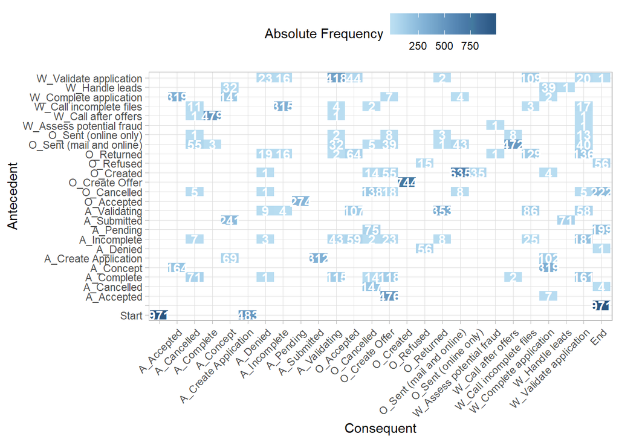

```r
eventlog %>% filter_trace_frequency(percentage = 0.9) %>% precedence_matrix() %>% plot()
```

We note for example, that the O_CreateOffer activity is always followed by the O_Created activity (So no anomaly occurs during the creation of an offer).

Also O_Created is almost always followed by the O_Sent activity (mail and online).

## Trace activities

Here, we are interested in trace frequencies through visualization.

The trace_explorer function in the processmapR library gives a color code to each activity and visualizes the different traces, indicating in addition the probability of occurrence.

We will limit ourselves only to the traces which cover 70% of the log to have a readable output.

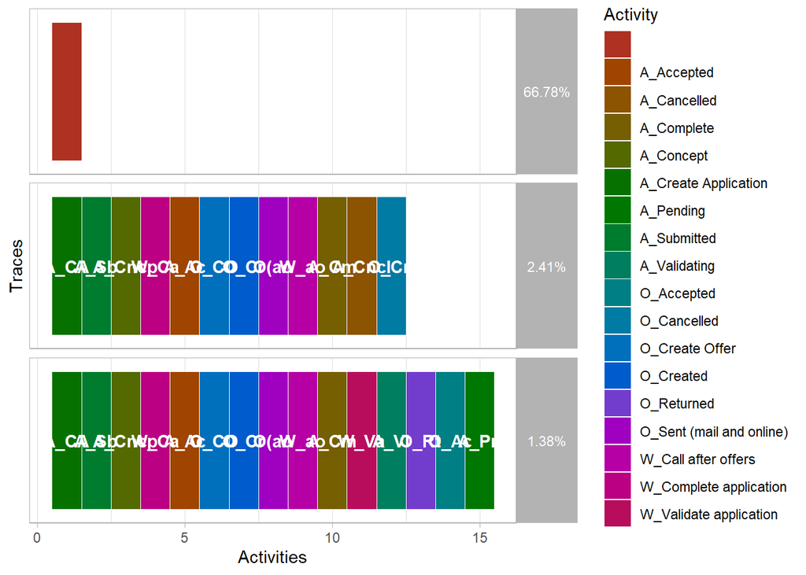

```r
trace_activites <- trace_explorer(eventlog = eventlog,coverage = 0.7)
plot(trace_activites)
```

## Throughput time in hours by type of application

```r
eventlog %>%
  filter_trace_frequency(percentage = 0.8) %>% group_by(.$`(case)_ApplicationType`) %>%
  throughput_time('log', units = 'hours')
```

```
## # A tibble: 3 x 10
##   `.$\`(case)_Applicati~   min    q1 median  mean    q3   max st_dev   iqr   NA.
##   <fct>                  <dbl> <dbl>  <dbl> <dbl> <dbl> <dbl>  <dbl> <dbl> <dbl>
## 1 "New credit"              48   240    480  590.   768  1416   405.   528    NA
## 2 ""                        NA    NA     NA  NaN     NA    NA   971     NA    NA
## 3 "Limit raise"            144   216    288  382.   528   792   227.   312    NA
```

We can observe a remarkable difference between the processing time of requests for new credits and increase of credit limit (Limit Raise).

```r
eventlog %>%
  filter_trace_frequency(percentage = 0.8) %>%
  group_by(.$`(case)_ApplicationType`) %>%
  throughput_time('log', units = 'hours')
```

[output not shown]